# 第10回 主成分の地図を読む

単位・負荷量・バイプロット

# 導入

## 前回は顔の向きを絵で読んだ

① 場面●○○○○

- 顔の画像を主成分分析で縮め、向きを顔として描いた
- 第1主成分は顔全体の明るさ、第2主成分は光の当たり方

## 表の向きは絵にならない

① 場面●●○○○

- 燃費や重さのように、単位も意味も違う列が並んだ表
- 向きを絵にしても、何も見えない
- 今日は、表の主成分の向きと得点の読み方を考える

## 場面：自動車雑誌の編集者

① 場面●●●○○

- あなたは自動車雑誌の編集者。次の号で、昔の車の特集を組む
- 性能表は数が多すぎて、読者には読みにくい
- 1枚の地図にして、「この車はこういう車」と説明したい

## 同僚のスクリプト

① 場面●●●●○

- 主成分分析を担当した同僚が、地図を作るスクリプトを残してくれた
- それを読んで使い、地図の読み方を考える

## 決めたいこと

① 場面●●●●●

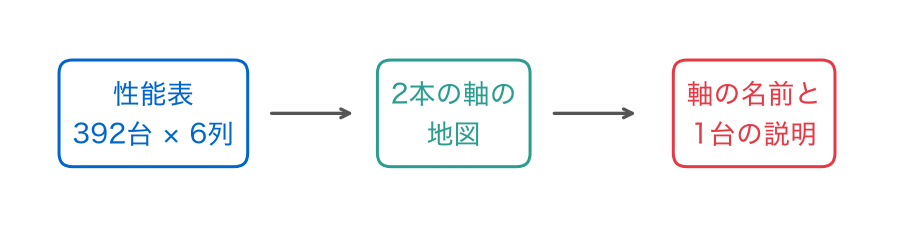

- 性能表を地図にし、軸に名前を付け、1台を説明する

## 手元のデータ

② 手元のデータ●○○○

- 1970〜1982年に売られた398台の車の性能表（UCIのAuto MPG。Quinlan, 1993。seabornが配布）
- 1行が1台

## 9つの列

② 手元のデータ●●○○

- 燃費・気筒数・排気量・馬力・重さ・加速・年式・地域・車名
- 加速は、0から時速60マイルまでの秒数。大きいほどゆるやか
- 地域は、アメリカ・日本・ヨーロッパ

## 単位は米国の単位

② 手元のデータ●●●○

- 燃費はマイル/ガロン、排気量は立方インチ、重さはポンド
- スクリプトの中で、日本の単位（km/L・cc・kg）に直す

## データをのぞく

② 手元のデータ●●●●

```
    mpg  cylinders  displacement  horsepower  weight  acceleration  model_year origin
0  18.0          8         307.0       130.0    3504          12.0          70    usa
1  15.0          8         350.0       165.0    3693          11.5          70    usa
2  18.0          8         318.0       150.0    3436          11.0          70    usa
```

- 元の表の先頭の3台。単位は米国の単位のまま

## 最後に出す答え

③ 今日の問い●○

- 地図の2本の軸の名前
- 地図が元の性能表をどれだけ残しているか
- 地図の上の1台を、軸の名前で説明する文

## 今日の問い

③ 今日の問い●●

単位も意味も違う6つの性能の列を、2本の軸の地図にしたとき、軸と地図をどう読めばよいか？

## もう1つのねらい：関数を読む

④ もう1つのねらい●○

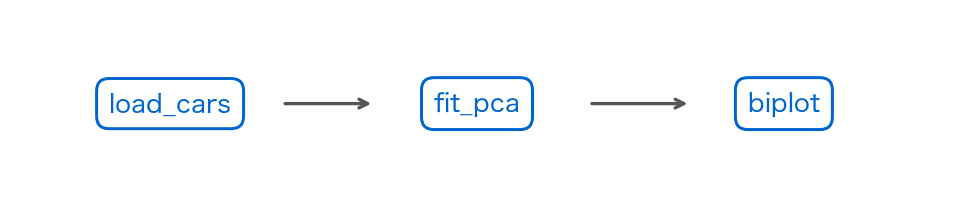

- 関数に分かれたスクリプトを、役割・入力・出力で読み、引数を変えて使えるようになる

## 3つの関数

④ もう1つのねらい●●

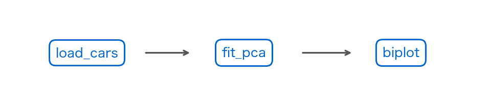

- 読む（`load_cars`）→ 主成分分析（`fit_pca`）→ 地図を描く（`biplot`）
- 引数を変えて、比べ直す

## この問いにどう近づくか

⑤ 今日の問い●○

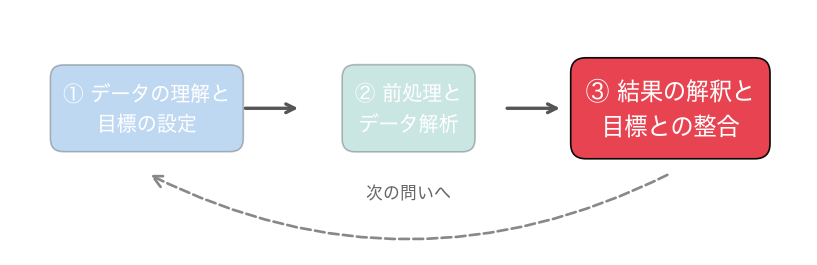

結果の解釈（地図をどう読むか）を中心に進みます。

## 今日の道筋

⑤ 今日の問い●●

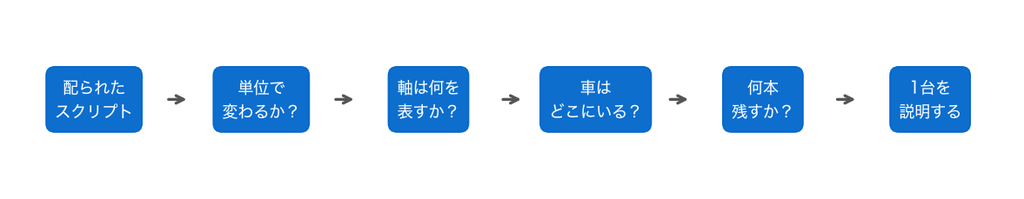

- 6つの小さな問いに答えていく

# 0. 準備

## まずは道具

- 第10回のノートを開き、上から順にセルを実行する
- 道具を呼び出し、データの置き場所を決める

## お手本：道具を呼び出す

0節 ① 道具●○

```python
import numpy as np
import pandas as pd
import matplotlib.pyplot as plt
from sklearn.preprocessing import StandardScaler
from sklearn.decomposition import PCA
```

- 標準化の`StandardScaler`と、主成分分析の`PCA`

## データの置き場所

0節 ① 道具●●

```python
# データはこのリポジトリから読み込む
DATA_DIR = ('https://raw.githubusercontent.com/k0heiun0/'
            'applied_exercise_preview/main/shared/data')
```

- 性能表のファイルは、この置き場所にある

## やってみよう：0節

0節 ② 確かめる●

- 0節のセルを上から実行する

動画の人は、ここで一時停止。

# 1. 配られたスクリプトは何をするか？

## まず実行して、読む

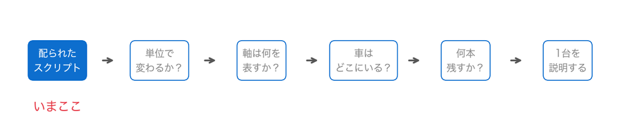

- 同僚のスクリプトを実行し、何をする関数が入っているかを読む

## 長いセルは、まず実行

1節 ① スクリプト●○

- 1つのセルに、3つの関数が入っている
- いまは実行するだけ。1つずつ、役割・入力・出力を読む
- 関数を読むときは、まず1行目の説明（docstring）を読む

## 名前：docstring

1節 ① スクリプト●●

```python
def fit_pca(cars, cols, scale=True):
    """選んだ列で主成分分析をする。scale=True なら標準化してから"""
```

- `def`の次の行の、`"""`で囲んだ文が、関数の説明（docstring）
- 何をする関数かが、1行で書いてある

## 1つ目：load_cars

1節 ② load_cars●○○○○○○

```python
def load_cars(path):
    """車の性能表を読み、日本の単位に直す。馬力が欠測の車は除く"""
    raw = pd.read_csv(path)
    raw = raw.dropna(subset=['horsepower']).reset_index(drop=True)
    region = {'usa': 'アメリカ', 'japan': '日本',
              'europe': 'ヨーロッパ'}
    cars = pd.DataFrame({
        '燃費': raw['mpg'] * 0.4251,           # マイル/ガロン → km/L
        '気筒数': raw['cylinders'],
        '排気量': raw['displacement'] * 16.39,  # 立方インチ → cc
        '馬力': raw['horsepower'],
        '重さ': raw['weight'] * 0.4536,         # ポンド → kg
        '加速': raw['acceleration'],    # 0〜60マイル毎時の秒数
        '年式': raw['model_year'] + 1900,
        '地域': raw['origin'].map(region),
        '車名': raw['name']})
    return cars
```

## 役割・入力・出力

1節 ② load_cars●●○○○○○

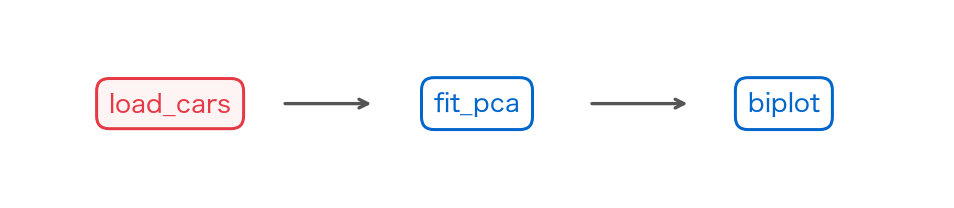

- 役割：性能表を読み、日本の単位に直す。馬力が欠測の車は除く
- 入力：ファイルの場所`path`。出力：日本語の列名の表`cars`

## 中身をかたまりで読む

1節 ② load_cars●●●○○○○

- `read_csv`で読み、`dropna`で馬力の欠測の行を除く（第3回）
- 列ごとに係数を掛けて単位を直す。1立方インチは16.39 cc
- 地域は`map`で日本語に直す

## お手本：load_carsを呼ぶ

1節 ② load_cars●●●●○○○

```python
cars = load_cars(f'{DATA_DIR}/auto_mpg.csv')
print(cars.shape)
cars.head(3).round(1)
```

## 392台 × 9列

1節 ② load_cars●●●●●○○

```
(392, 9)
    燃費  気筒数     排気量     馬力      重さ    加速    年式    地域
0  7.7    8  5031.7  130.0  1589.4  12.0  1970  アメリカ
1  6.4    8  5736.5  165.0  1675.1  11.5  1970  アメリカ
2  7.7    8  5212.0  150.0  1558.6  11.0  1970  アメリカ
```

- 元の表は398台。馬力が欠測の6台を除いた（車名の列は省いて表示）

## 欠測は1.5%

1節 ② load_cars●●●●●●○

```python
print(round(6 / 398 * 100, 1), '%')
```

```
1.5 %
```

- 398台のうち1.5%なので、この回では除いて進める

## 地域ごとの台数

1節 ② load_cars●●●●●●●

```
地域
アメリカ     245
日本        79
ヨーロッパ     68
```

- アメリカ245台、日本79台、ヨーロッパ68台

## 変えてみる：平均と標準偏差

1節 ③ 列の大きさ●○

```python
FEAT = ['燃費', '気筒数', '排気量', '馬力', '重さ', '加速']
cars[FEAT].describe().loc[['mean', 'std']].round(1)
```

```
        燃費  気筒数     排気量     馬力      重さ    加速
mean  10.0  5.5  3186.4  104.5  1350.6  15.5
std    3.3  1.7  1715.1   38.5   385.3   2.8
```

- 性能の6列の名前を`FEAT`に入れておく

## 数の大きさがまったく違う

1節 ③ 列の大きさ●●

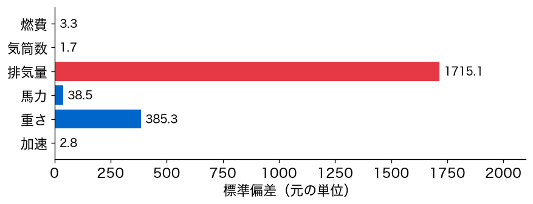

- 標準偏差は、排気量1715.1、重さ385.3。燃費は3.3、気筒数は1.7

## 2つ目：fit_pca

1節 ④ fit_pca●○○○○

```python
def fit_pca(cars, cols, scale=True):
    """選んだ列で主成分分析をする。scale=True なら標準化してから"""
    X = cars[cols].values
    if scale:
        X = StandardScaler().fit_transform(X)
    pca = PCA().fit(X)
    return pca, pca.transform(X)
```

## 役割・入力・出力

1節 ④ fit_pca●●○○○

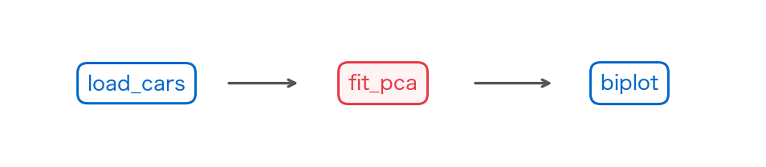

- 役割：選んだ列で主成分分析をする。`scale=True`なら標準化してから
- 入力：表、列の名前のリスト、標準化するか。出力：`pca`と得点の表

## 引数の既定値

1節 ④ fit_pca●●●○○

- `scale=True`は、引数の既定値
- 呼ぶときに`scale`を書かなければ`True`、`scale=False`と書けば標準化しない
- 関数の中の`if scale:`が、その切り替え

## 2つの値を返す

1節 ④ fit_pca●●●●○

```python
    return pca, pca.transform(X)
```

- `return`のあとに、2つの値を並べて返す
- 受け取る側は`pca, S = fit_pca(...)`と、2つの名前を並べる

## お手本：fit_pcaを呼ぶ

1節 ④ fit_pca●●●●●

```python
pca, S = fit_pca(cars, FEAT)
print(S.shape)
print(pca.explained_variance_ratio_[:2].round(3))
```

```
(392, 6)
[0.798 0.121]
```

- 得点は392台 × 6本。寄与率は0.798と0.121

## 3つ目：biplot

1節 ⑤ biplot●○○○○○

```python
def biplot(scores, pca, cols, groups):
    """第1・第2主成分の得点を点で、各列を矢印で、1枚に重ねて描く"""
    sd = scores.std(axis=0)                     # 得点の標準偏差
    arrows = pca.components_[:2].T * sd[:2]     # 列と得点の相関
    for g in ['アメリカ', '日本', 'ヨーロッパ']:
        m = groups == g
        plt.scatter(scores[m, 0], scores[m, 1], s=12, alpha=0.5,
                    label=g)
    for (x, y), name in zip(arrows * 3, cols):
        plt.arrow(0, 0, x, y, color='black', head_width=0.08)
        plt.text(x * 1.2, y * 1.2, name, ha='center', fontsize=12)
    plt.axhline(0, color='gray', lw=0.5)
    plt.axvline(0, color='gray', lw=0.5)
    plt.xlabel('第1主成分')
    plt.ylabel('第2主成分')
    plt.legend()
    plt.show()
```

## 役割・入力・出力

1節 ⑤ biplot●●○○○○

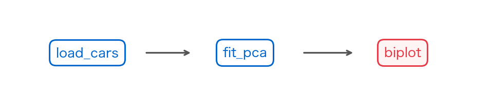

- 役割：第1・第2主成分の得点を点で、各列を矢印で、1枚に重ねて描く
- 入力：得点、`pca`、列の名前、色分けの区分。出力：図。中身は4節で読む

## お手本：biplotを呼ぶ

1節 ⑤ biplot●●●○○○

```python
biplot(S, pca, FEAT, cars['地域'].values)
```

[output not shown]

- 392台を、地域で色分けして地図に描く

## 3つの関数で地図ができた

1節 ⑤ biplot●●●●○○

## 点は車、矢印は列

1節 ⑤ biplot●●●●●○

- アメリカ車は右に、日本車とヨーロッパ車は左に集まっている

## このまま見せてよいか？

1節 ⑤ biplot●●●●●●

- 横の軸と縦の軸が何を表すのかが、分からない
- そもそも、標準化してよかったのか
- 次の節から、順に確かめる

## やってみよう：1節

1節 ⑥ 確かめる●

- 1節のセルを上から実行し、地図を出す
- 3つの関数の役割・入力・出力を、自分の言葉で言ってみる

動画の人は、ここで一時停止。

# 2. 単位で答えは変わるか？

## 標準化しないと？

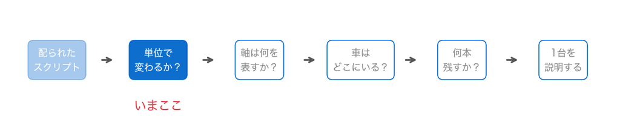

- `fit_pca`は、標準化してから主成分分析をしていた
- 引数`scale=False`で、標準化しないとどうなるかを確かめる

## お手本：標準化しないで

2節 ① 標準化しない●○○○○

```python
pca_raw, S_raw = fit_pca(cars, FEAT, scale=False)
print(pca_raw.explained_variance_ratio_[:2].round(3))
print(pd.Series(pca_raw.components_[0], index=FEAT).round(3))
```

- `pca.components_[0]`は、第1主成分の向き（第9回）。6列それぞれの数

## 1本で99%以上

2節 ① 標準化しない●●○○○

```
[0.994 0.006]
燃費    -0.002
気筒数    0.001
排気量    0.978
馬力     0.020
重さ     0.206
加速    -0.001
```

- 第1主成分の寄与率は0.994

## ほぼ排気量そのもの

2節 ① 標準化しない●●●○○

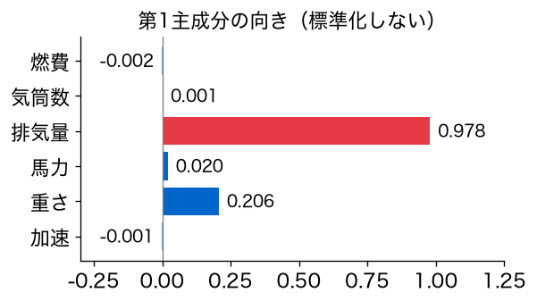

- 排気量が0.978で、ほかはほとんど0

## 横の軸は排気量の順

2節 ① 標準化しない●●●●○

```
0.9999
```

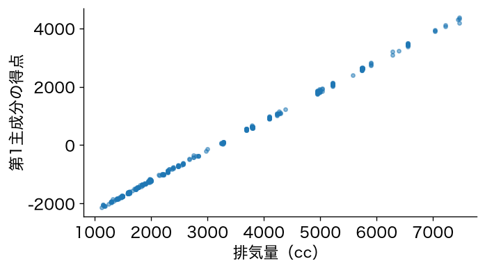

- 第1主成分の得点と排気量の相関は0.9999

## 排気量を並べただけ

2節 ① 標準化しない●●●●●

- 標準化しない地図の横の軸は、車を排気量の順に並べただけ
- ほかの5列の情報は、ほとんど入っていない

## なぜ排気量だけ？

2節 ② なぜ排気量か●○○

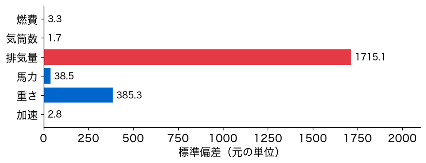

- 主成分分析は、ずれの二乗和をいちばん多く受け持つ向きを探す（第9回）

## ccで測ると数が大きい

2節 ② なぜ排気量か●●○

- 排気量はccで測るので、標準偏差が1715.1もある
- 燃費（3.3）や気筒数（1.7）のずれは、小さすぎて効かない

## 大事だからではない

2節 ② なぜ排気量か●●●

- 排気量が、車の性能でいちばん大事だからではない
- ccで測ると、数が大きいから

## TODO①：立方インチに戻すと

2節 ③ 単位を変える●○○○○

```python
# TODO: 排気量を立方インチに戻し、標準化しない主成分分析をする
# ヒント: cars_ci = cars.copy()
#         cars_ci['排気量'] = cars['排気量'] / 16.39
#         pca_ci, S_ci = fit_pca(cars_ci, FEAT, scale=False)
...
```

- 寄与率と、第1主成分の向きを表示する

## やってみよう：2節とTODO①

2節 ③ 単位を変える●●○○○

- 標準化しないお手本を実行する
- TODO①で、排気量を立方インチに戻して比べる

動画の人は、ここで一時停止。

## 答え合わせ：TODO①

2節 ③ 単位を変える●●●○○

```python
cars_ci = cars.copy()
cars_ci['排気量'] = cars['排気量'] / 16.39
pca_ci, S_ci = fit_pca(cars_ci, FEAT, scale=False)
print(pca_ci.explained_variance_ratio_[:2].round(3))
print(pd.Series(pca_ci.components_[0], index=FEAT).round(3))
```

```
[0.989 0.009]
燃費    -0.007
気筒数    0.004
排気量    0.247
馬力     0.084
重さ     0.965
加速    -0.003
```

## 重さの軸に入れ替わった

2節 ③ 単位を変える●●●●○

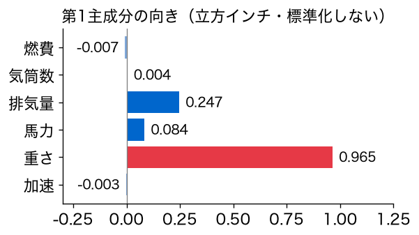

- 重さが0.965、排気量は0.247に下がる。寄与率は0.989

## 単位を変えただけで

2節 ③ 単位を変える●●●●●

- 同じ392台なのに、排気量の単位を変えただけ
- 第1主成分は「排気量の軸」から「重さの軸」に入れ替わった
- 立方インチにすると排気量の数は16.39分の1。重さのほうが大きくなる

## おさらい：標準化

2節 ④ 標準化する●○○○

- 各列から平均を引き、標準偏差で割る（第4回・第7回）
- 標準化した列は、どれも標準偏差が1。単位が消える

## お手本：標準化すると

2節 ④ 標準化する●●○○

```python
cars_ci = cars.copy()
cars_ci['排気量'] = cars['排気量'] / 16.39
pca_cc, _ = fit_pca(cars, FEAT)
pca_ci, _ = fit_pca(cars_ci, FEAT)
print(pca_cc.explained_variance_ratio_[:2].round(3))
print(pca_ci.explained_variance_ratio_[:2].round(3))
```

- `_`は、受け取るけれど使わない値の置き場

## ccでも立方インチでも同じ

2節 ④ 標準化する●●●○

```
[0.798 0.121]
[0.798 0.121]
```

- どちらも0.798と0.121。単位によらない答えになった

## 単位が違えば標準化

2節 ④ 標準化する●●●●

- 単位も意味も違う列が並んだ表では、標準化してから主成分分析をする
- `fit_pca`の既定値が`scale=True`だったのは、このため
- 顔の画像のように、どの列も同じ単位なら、標準化しなくてよい

# 3. 軸は何を表すか？

## 2本の軸を読む

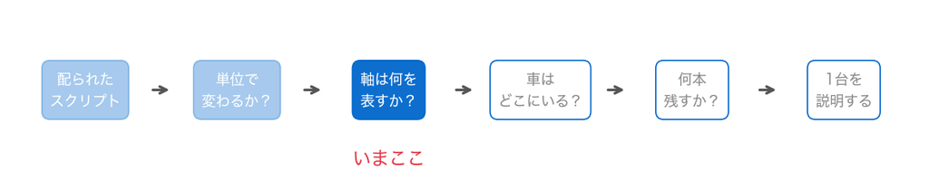

- 標準化して、単位によらない地図ができた
- 次は、地図の2本の軸が何を表すかを読む

## 得点は重み付きの和

3節 ① 負荷量●○○○○○

- 第9回：得点は「ずれ`@`向きの転置」
- 標準化した列を$z_{i1}, \dots, z_{i6}$、第1主成分の向きの成分を$a_{11}, \dots, a_{61}$と書く

$$t_{i1} = a_{11} z_{i1} + a_{21} z_{i2} + \cdots + a_{61} z_{i6}$$

## 名前：負荷量

3節 ① 負荷量●●○○○○

- 向きの成分$a_{j1}$は、得点を作るときの、列$j$の重み
- この重みを、主成分負荷量、または負荷量と呼ぶ
- 重みが大きい列ほど、その軸に強く効く

## お手本：負荷量の表

3節 ① 負荷量●●●○○○

```python
load = pd.DataFrame(pca.components_[:2].T, index=FEAT,
                    columns=['第1', '第2'])
load.round(3)
```

- `pca.components_[:2]`は2行6列。`.T`で6行2列にする

## 6行2列の表

3節 ① 負荷量●●●●○○

```
        第1     第2
燃費  -0.399 -0.245
気筒数  0.431  0.148
排気量  0.444  0.108
馬力   0.434 -0.166
重さ   0.430  0.286
加速  -0.292  0.893
```

## お手本：棒で描く

3節 ① 負荷量●●●●●○

```python
load.plot.barh(subplots=True, layout=(1, 2), figsize=(10, 3.5),
               legend=False, sharey=True)
plt.show()
```

- `plot.barh`：表の列ごとに横棒を描く
- `subplots=True`：第1と第2を別の図に分ける

## 負荷量の棒

3節 ① 負荷量●●●●●●

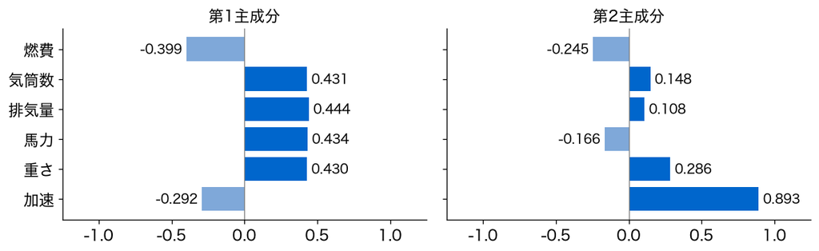

## 第1主成分に効く列は？

3節 ② 第1主成分●○○

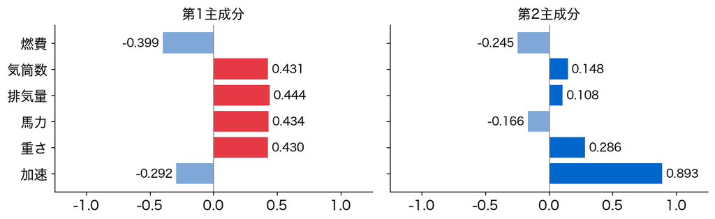

- 気筒数・排気量・馬力・重さが0.43〜0.44で、ほぼ同じ大きさ

## 燃費と加速は逆の符号

3節 ② 第1主成分●●○

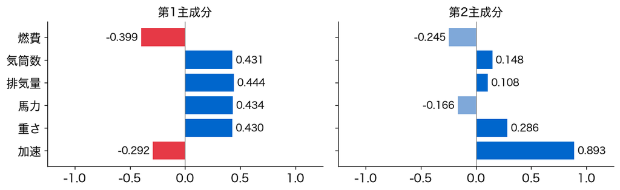

- 燃費は−0.399、加速は−0.292

## 大きさ・パワーの軸

3節 ② 第1主成分●●●

- 気筒数が多く、排気量が大きく、馬力が強く、重い車ほど、得点が大きい
- そのような車は、燃費が悪く、加速の秒数が短い
- 第1主成分は「車の大きさ・パワーの軸」

## 第2主成分は加速

3節 ③ 第2主成分●○○○

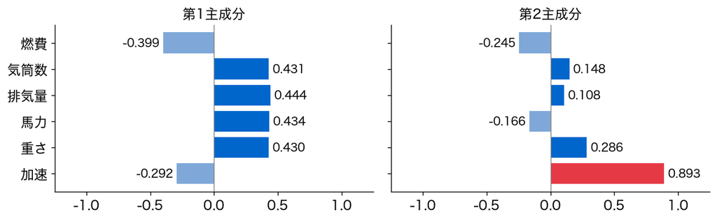

- 加速の負荷量が0.893で、飛び抜けて大きい。ほかは0.3より小さい

## 加速のゆるやかさの軸

3節 ③ 第2主成分●●○○

- 得点が大きいのは、時速60マイルまでに時間がかかる車
- 第2主成分は「加速のゆるやかさの軸」

## 名前はあだ名

3節 ③ 第2主成分●●●○

- 軸の名前は、負荷量を見て人が付けるあだ名
- データが名前を教えてくれるわけではない
- 読者に伝わる言葉を選ぶ

## 符号は決まらない

3節 ③ 第2主成分●●●●

- 向きは逆向きにしても同じ直線（第9回）
- 符号がすべて逆になっても、地図が裏返るだけ
- 読むのは、どの列が同じ符号で並び、どの列が逆の符号か

## 負荷量の二乗の和は1

3節 ④ 長さ1●○

```
第1    1.0
第2    1.0
```

- 向きは長さ1（第9回）。6つの負荷量の二乗を足すと1
- だから、負荷量は−1から1のあいだに収まる

## 重みを分け合う

3節 ④ 長さ1●●

- 二乗の和が1なので、6列で重みを分け合う
- 第1主成分は4列でほぼ等しく分け合い、第2主成分は加速がほとんどを取った

## 負荷量と相関は違う

3節 ⑤ 相関●○○○○

- 負荷量は、得点を作るときの重み
- 列と得点の相関係数も、軸を読む手がかりになる

$$\text{相関} = a_{jk} \times (\text{得点の標準偏差})$$

## 標準偏差は√固有値

3節 ⑤ 相関●●○○○

- 第$k$主成分の得点の標準偏差は、$\sqrt{固有値}$
- 標準化した列なら、負荷量にこれを掛けると相関になる

## お手本：相関の表

3節 ⑤ 相関●●●○○

```python
sd = S.std(axis=0)
print(sd[:2].round(3))
(load * sd[:2]).round(3)
```

- `S.std(axis=0)`：得点の、軸ごとの標準偏差

## 排気量0.971、加速0.762

3節 ⑤ 相関●●●●○

```
[2.188 0.854]
        第1     第2
燃費  -0.873 -0.209
気筒数  0.942  0.127
排気量  0.971  0.093
馬力   0.950 -0.142
重さ   0.941  0.244
加速  -0.639  0.762
```

- 得点の標準偏差は2.188と0.854

## 同じ軸なら順番は同じ

3節 ⑤ 相関●●●●●

- 同じ軸の中では、負荷量と相関の大小の順は同じ（同じ数を掛けただけ）
- 軸どうしを比べるときは、相関のほうが分かりやすいことがある
- 本によっては相関のほうを負荷量と呼ぶ。定義を確かめる

## TODO②：相関を直接確かめる

3節 ⑥ 直接確かめる●○○○

```python
# TODO: 排気量と第1主成分、加速と第2主成分の相関係数を出す
# ヒント: np.corrcoef(cars['排気量'], S[:, 0])[0, 1]
...
```

- 表の0.971・0.762と同じになるか

## やってみよう：3節とTODO②

3節 ⑥ 直接確かめる●●○○

- 3節のお手本を実行し、負荷量と相関の表を見る
- TODO②で、相関を`np.corrcoef`で直接確かめる

動画の人は、ここで一時停止。

## 答え合わせ：TODO②

3節 ⑥ 直接確かめる●●●○

```python
print(np.corrcoef(cars['排気量'], S[:, 0])[0, 1].round(3))
print(np.corrcoef(cars['加速'], S[:, 1])[0, 1].round(3))
```

```
0.971
0.762
```

## 元の列でも同じ相関

3節 ⑥ 直接確かめる●●●●

- 表と同じ0.971と0.762
- 標準化は引いて割るだけなので、元の列でも標準化した列でも、相関は同じ

# 4. 車はどこにいるか？

## 地図を読み直す

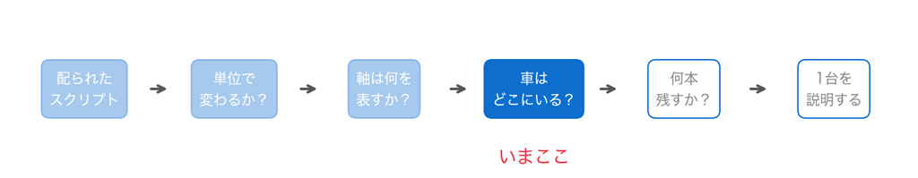

- 2本の軸に名前が付いた
- 1節の地図を、軸の名前を手がかりに読み直す

## biplotの中身：3つのかたまり

4節 ① biplotを読む●○

```python
    sd = scores.std(axis=0)                     # 得点の標準偏差
    arrows = pca.components_[:2].T * sd[:2]     # 列と得点の相関
    for g in ['アメリカ', '日本', 'ヨーロッパ']:
        m = groups == g
        plt.scatter(scores[m, 0], scores[m, 1], s=12, alpha=0.5,
                    label=g)
    for (x, y), name in zip(arrows * 3, cols):
        plt.arrow(0, 0, x, y, color='black', head_width=0.08)
        plt.text(x * 1.2, y * 1.2, name, ha='center', fontsize=12)
```

- 1：3節の相関の表を作る。2：地域ごとに散布図。3：列ごとに矢印と名前

## 矢印の先は相関

4節 ① biplotを読む●●

- 矢印の先は、列と第1・第2主成分の相関
- 図に合わせて3倍に伸ばしてある
- 点と矢印を1枚に重ねた図を、バイプロットと呼ぶ

## お手本：地域ごとの平均

4節 ② 地域●○○○○

```python
biplot(S, pca, FEAT, cars['地域'].values)
pd.DataFrame(S[:, :2], columns=['第1', '第2']).groupby(
    cars['地域']).mean().round(2)
```

- 地図をもう一度描き、地域ごとの得点の平均を出す

## 地域ごとの平均

4節 ② 地域●●○○○

```
         第1    第2
地域
アメリカ   1.03  0.12
ヨーロッパ -1.58 -0.01
日本    -1.82 -0.38
```

- アメリカは1.03、日本は−1.82、ヨーロッパは−1.58

## アメリカ車は右

4節 ② 地域●●●○○

- アメリカ車は右（大きく、パワーのある側）

## 日本・ヨーロッパ車は左

4節 ② 地域●●●●○

- 日本車とヨーロッパ車は左（小さく、燃費のよい側）
- 第2主成分の平均は、どの地域も0に近い

## 矢印の向きの車ほど大きい

4節 ② 地域●●●●●

- 重さの矢印の先にアメリカ車、燃費の矢印の先に日本・ヨーロッパ車

## 矢印の角度は相関の目安

4節 ③ 角度●○○○○○○○

- 同じ向きの矢印：相関が正
- 逆向きの矢印：相関が負
- 直角に近い矢印：相関は0に近い

## 燃費と重さは逆向き

4節 ③ 角度●●○○○○○○

- 燃費の矢印は、重さの矢印とほぼ逆を向いている

## TODO③：相関の表と比べる

4節 ③ 角度●●●○○○○○

```python
# TODO: 6列の相関係数の表を出し、矢印の角度と比べる
# ヒント: cars[FEAT].corr().round(2)
...
```

- 燃費と重さ、加速と馬力の相関係数を、矢印の角度と比べる

## やってみよう：4節とTODO③

4節 ③ 角度●●●●○○○○

- 4節のお手本を実行し、地域ごとの平均を見る
- TODO③で、相関の表と矢印の角度を比べる

動画の人は、ここで一時停止。

## 答え合わせ：TODO③

4節 ③ 角度●●●●●○○○

```python
cars[FEAT].corr().round(2)
```

```
       燃費   気筒数   排気量    馬力    重さ    加速
燃費   1.00 -0.78 -0.81 -0.78 -0.83  0.42
気筒数 -0.78  1.00  0.95  0.84  0.90 -0.50
排気量 -0.81  0.95  1.00  0.90  0.93 -0.54
馬力  -0.78  0.84  0.90  1.00  0.86 -0.69
重さ  -0.83  0.90  0.93  0.86  1.00 -0.42
加速   0.42 -0.50 -0.54 -0.69 -0.42  1.00
```

## 燃費と重さは−0.83

4節 ③ 角度●●●●●●○○

- 相関−0.83で、矢印はほぼ逆向き

## 加速と馬力は−0.69

4節 ③ 角度●●●●●●●○

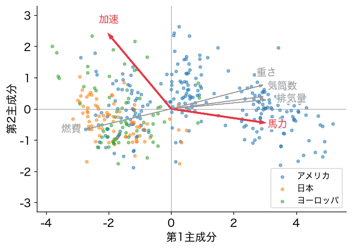

- 相関−0.69で、矢印は鈍い角度で開いている

## 0.9以上はほぼ重なる

4節 ③ 角度●●●●●●●●

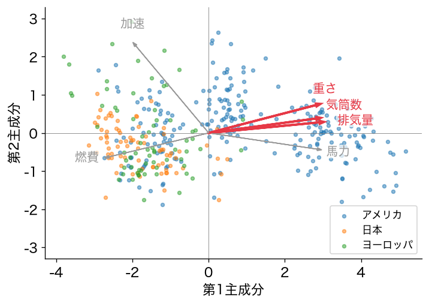

- 気筒数・排気量・重さどうしは0.9以上。矢印はほぼ重なる

## 矢印の長さは？

4節 ④ 長さ●○○○○

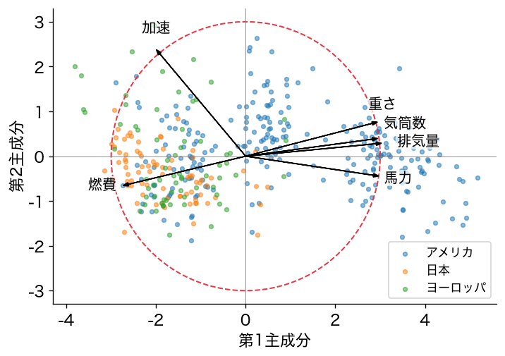

- 破線の円は、相関の二乗の和が1になる長さ（3倍に伸ばしたもの）

## 長さの二乗は残せている割合

4節 ④ 長さ●●○○○

- 矢印の先は、列と第1・第2主成分の相関
- 2つの相関の二乗の和が、標準化した列の散らばりのうち、2本の軸で表せている割合
- 矢印が長い列ほど、地図の上でよく表せている

## お手本：残せている割合

4節 ④ 長さ●●●○○

```python
((load * sd[:2]) ** 2).sum(axis=1).round(3)
```

```
燃費     0.806
気筒数    0.904
排気量    0.951
馬力     0.923
重さ     0.945
加速     0.989
```

- `** 2`で二乗し、`sum(axis=1)`で横の方向（2本の軸）に足す（第9回）

## どの列も8割以上

4節 ④ 長さ●●●●○

- 加速0.989、排気量0.951で、ほぼ全部を表せている
- いちばん小さい燃費でも0.806

## 地図は近似

4節 ④ 長さ●●●●●

- 燃費の2割ほどは、この地図に表れていない
- 2本の軸の地図は、元の6列の近似

# 5. 何本の軸を残すか？

## 3本、4本と増やすべきか

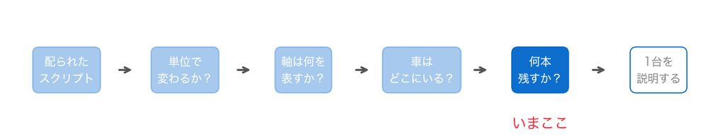

- 2本の地図で、どの列も8割以上が残っていた
- 軸を増やすべきかを、寄与率と固有値から考える

## お手本：6本すべての寄与率

5節 ① 寄与率●○○

```python
ratio = pca.explained_variance_ratio_
print(ratio.round(3))
print(ratio.cumsum().round(3))
plt.bar(range(1, 7), ratio)
plt.plot(range(1, 7), ratio.cumsum(), 'o-', color='#e63946')
plt.xlabel('主成分')
plt.ylabel('寄与率')
plt.show()
```

## 名前：スクリープロット

5節 ① 寄与率●●○

```
[0.798 0.121 0.043 0.021 0.011 0.006]
[0.798 0.919 0.963 0.983 0.994 1.   ]
```

- 寄与率を軸の順に並べた図を、スクリープロットと呼ぶ

## 3本目からはほとんど残らない

5節 ① 寄与率●●●

- 0.798、0.121のあとは0.043、0.021。累積は2本で0.919、3本で0.963

## 目安①：累積寄与率

5節 ② 目安●○○

- たとえば9割を超えるまで残す（第9回）
- ここでは2本（0.919）

## 目安②：肘

5節 ② 目安●●○

- 棒が急に低くなる手前まで残す。ここでは第1主成分のあとで急に低くなる

## 目安③：固有値1以上

5節 ② 目安●●●

- 標準化したとき、固有値（得点の分散）が1以上の軸を残す
- 元の1列ぶんの分散（1）より多くを受け持つ軸だけを残す考え方
- 固有値は`pca.explained_variance_`に入っている

## TODO④：固有値1以上の数

5節 ③ 固有値●○○○

```python
# TODO: 固有値を表示し、1以上の軸の数を数える
# ヒント: print(pca.explained_variance_.round(3))
#         (pca.explained_variance_ >= 1).sum()
...
```

## やってみよう：5節とTODO④

5節 ③ 固有値●●○○

- 5節のお手本を実行し、スクリープロットを見る
- TODO④で、固有値が1以上の軸を数える

動画の人は、ここで一時停止。

## 答え合わせ：TODO④

5節 ③ 固有値●●●○

```python
print(pca.explained_variance_.round(3))
print((pca.explained_variance_ >= 1).sum())
```

```
[4.801 0.73  0.259 0.125 0.063 0.036]
1
```

## 1以上は1本だけ

5節 ③ 固有値●●●●

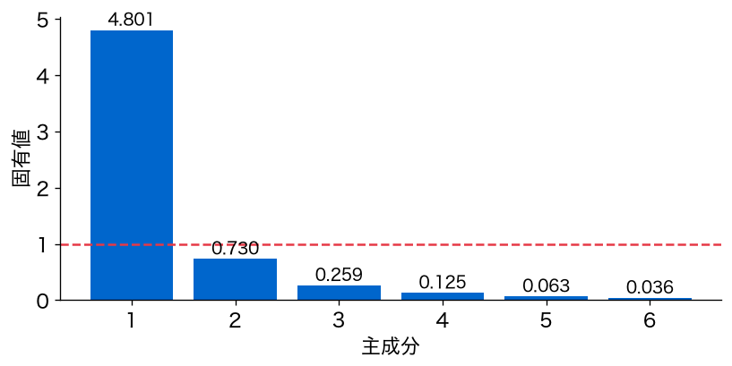

- 固有値は4.801、0.73、0.259…。1以上は第1主成分だけ

## 目安が食い違う

5節 ④ 決める●○

- 固有値1以上なら1本、累積寄与率9割なら2本
- 目安は、目的に合わせて選ぶもの

## 地図なら2本

5節 ④ 決める●●

- 読者に見せる地図なので、2本にする
- 平面に描け、累積寄与率は0.919、どの列も8割以上が残る
- 第2主成分（0.121）は、第1主成分で表しきれない加速を受け持つ

## 3本目は何を表す？

5節 ⑤ 第3主成分●○○

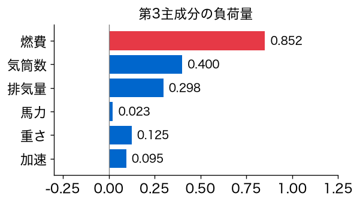

- 第3主成分では、燃費の負荷量が0.852で大きい

## 燃費の残り

5節 ⑤ 第3主成分●●○

```
0.433
0.994
```

## それでも地図は2本

5節 ⑤ 第3主成分●●●

- 第3主成分の寄与率は0.043と小さい
- 燃費を細かく比べたいときは、地図ではなく性能表の燃費を見る

# 6. 地図の上で1台をどう説明するか？

## 点は何を表すか

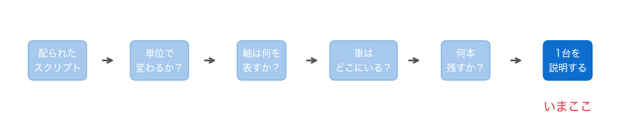

- 地図の上の1台を、軸の名前で読者に説明する
- まず、1台の位置を自分で計算する

## お手本：カローラの位置

6節 ① 手で計算●○○○

```python
i = cars.index[cars['車名'] == 'toyota corolla 1200'][0]
z = (cars.loc[i, FEAT] - cars[FEAT].mean()) / cars[FEAT].std(ddof=0)
print(i)
print((z.values.astype(float) @ pca.components_[:2].T).round(2))
print(S[i, :2].round(2))
```

- トヨタ・カローラ1200を探し、6列を標準化して、負荷量との積で得点を出す

## 1行ずつ読む

6節 ① 手で計算●●○○

- `std(ddof=0)`：`StandardScaler`と同じ標準偏差の計算（第7回）
- `z.values @ pca.components_[:2].T`：標準化した6つの値と2本の向きの積（第9回）
- `.astype(float)`：計算できる小数の並びにそろえる

## 手の計算と同じ

6節 ① 手で計算●●●○

```
52
[-2.71  0.39]
[-2.71  0.39]
```

- 52行目。手で計算した得点は（−2.71, 0.39）で、`fit_pca`と同じ

## 点は重み付きの和の位置

6節 ① 手で計算●●●●

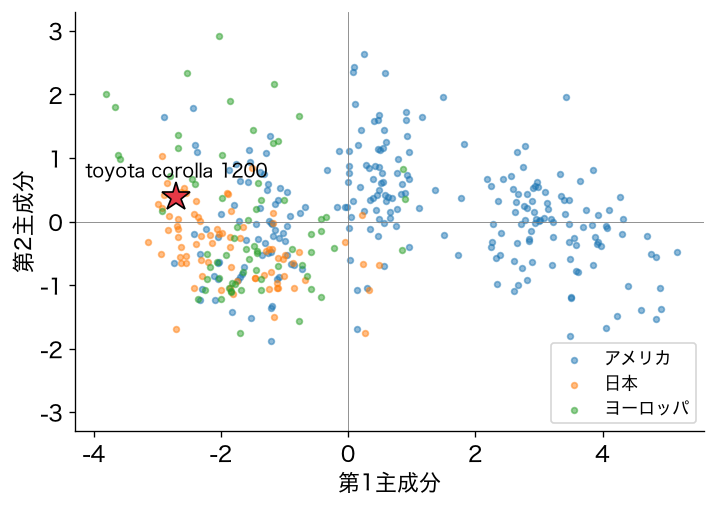

- 地図の点は、標準化した性能を、負荷量の重みで足した位置

## お手本：2台を並べる

6節 ② 2台●○○○○○

```python
two = cars['車名'].isin(['toyota corolla 1200', 'chevrolet impala'])
show = cars.loc[two, FEAT + ['年式', '地域', '車名']].round(1)
show['第1'] = S[two, 0].round(2)
show['第2'] = S[two, 1].round(2)
show.drop_duplicates('車名')
```

- インパラは同じ車名の車が何台かあるので、`drop_duplicates`で最初の1台だけ残す

## カローラとインパラ

6節 ② 2台●●○○○○

```
                       燃費     排気量      重さ    年式    第1    第2
車名
chevrolet impala      6.0  7441.1  1975.0  1970  4.92 -1.37
toyota corolla 1200  13.2  1163.7   804.2  1971 -2.71  0.39
```

## 左端と右端

6節 ② 2台●●●○○○

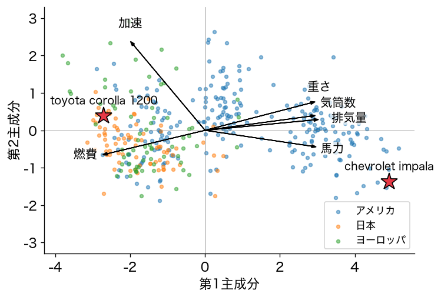

## カローラ：小さく燃費がよい

6節 ② 2台●●●●○○

- 1971年、日本。燃費13.2 km/L、排気量1163.7 cc、重さ804.2 kg
- 第1主成分は−2.71。地図の左端近く

## インパラ：大きくパワーがある

6節 ② 2台●●●●●○

- 1970年、アメリカ。燃費6 km/L、排気量7441.1 cc、重さ1975 kg
- 第1主成分は4.92で右端近く。第2主成分は−1.37で、すばやく加速する側